# NYC Flight Delay Report

### Check the distribution of delays per season

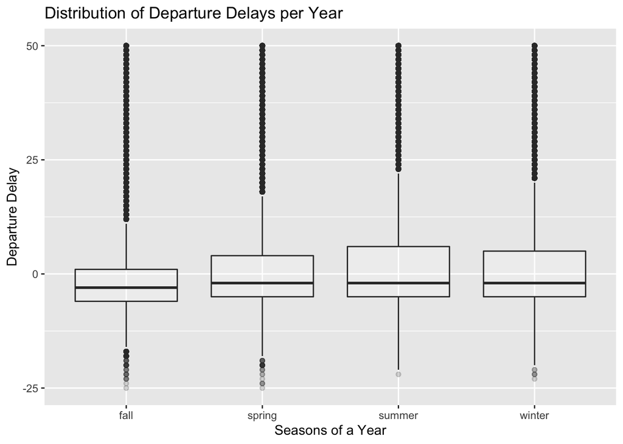

```r
flights_by_season <- mutate(flights, season = ifelse(month %in% 9:11, "fall",
  ifelse(month %in% 3:5, "spring",
    ifelse(month %in% 6:8, "summer", "winter")
  )))

ggplot(flights_by_season, aes(x=season, y=dep_delay))+
  geom_boxplot(alpha = 0.2) + ylim(-25,50)+
  labs(title = "Distribution of Departure Delays per Year", y = "Departure Delay", x = "Seasons of a Year")
```

## Key investigations results from the data

### Which month has the most delays?

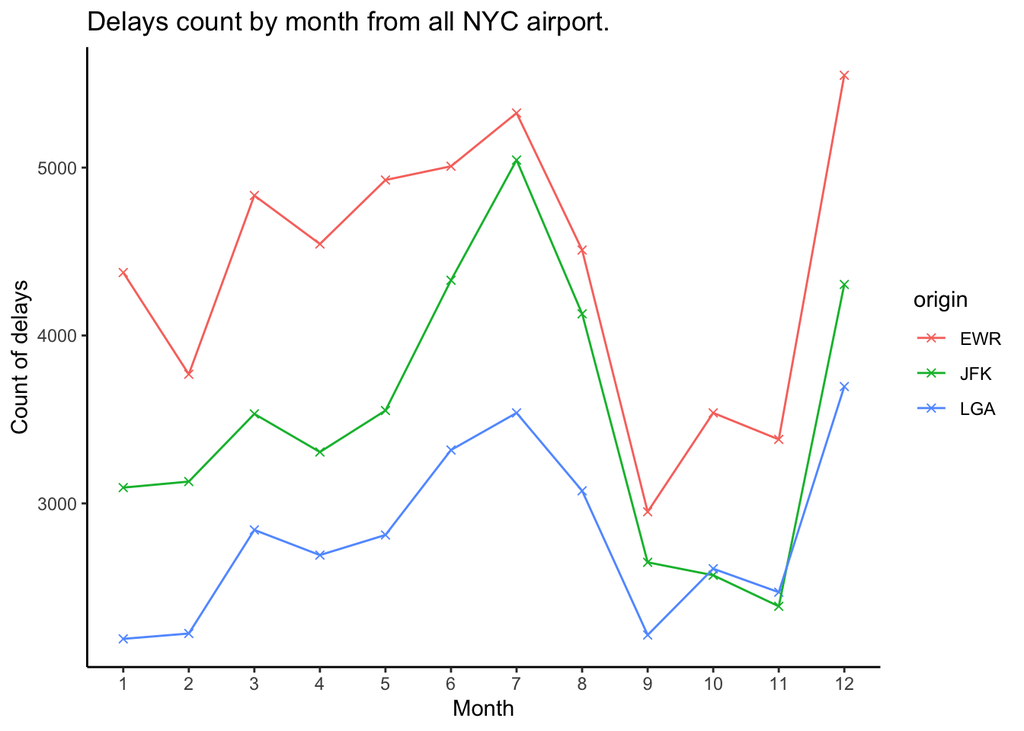

```r
flights %>%
  filter(dep_delay > 0) %>%
  group_by(month, origin) %>%
  summarise(count = n()) %>%
  ggplot(aes(month, count, color = origin)) +
  geom_point(shape = 4) +
  geom_line() +
  scale_x_continuous("Month", n.breaks = 12) +
  scale_y_continuous("Count of delays") +
  ggtitle("Delays count by month from all NYC airport.") +
  theme_classic()
```

## Key investigations results from the data

### What is the distribution of all delays?

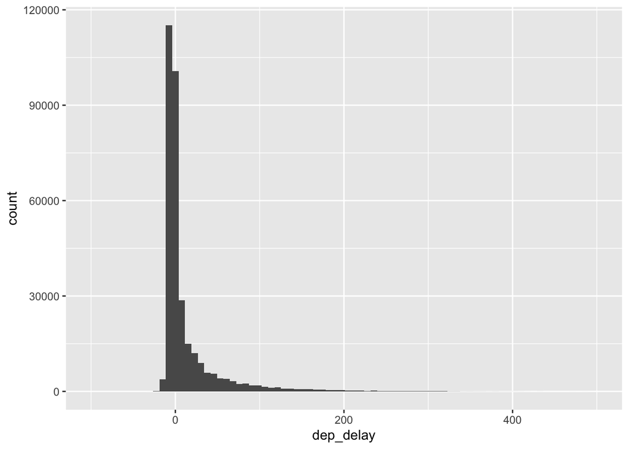

```r
ggplot(flights, aes(x = dep_delay)) +
  geom_histogram(bins = 80) +
  scale_x_continuous(limits = c(-100, 500))
```

## Key investigations results from the data

### What is the average delay for each airline?

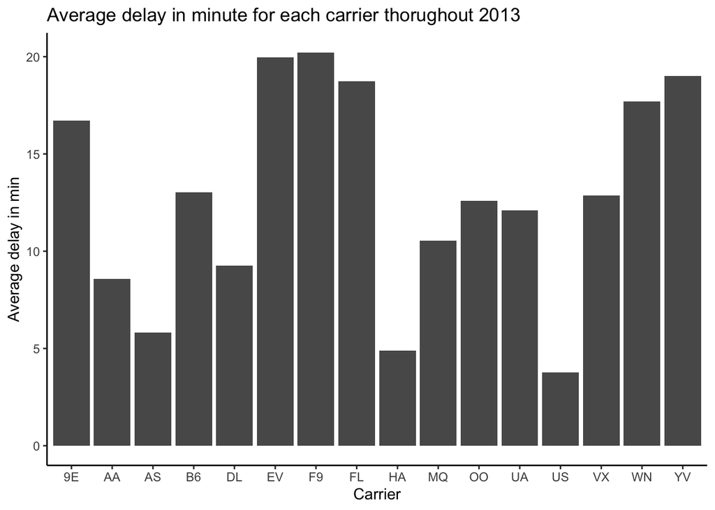

```r
flights %>%
  group_by(carrier) %>%
  summarise(avg = mean(dep_delay), std = sd(dep_delay)) %>%
  ggplot(aes(carrier, avg)) +
  geom_col() +
  # geom_errorbar(aes(ymin=avg-std, ymax=avg+std))+
  scale_y_continuous("Average delay in min") +
  scale_x_discrete("Carrier") +
  ggtitle("Average delay in minute for each carrier thorughout 2013") +
  theme_classic()
```

## Conclusion

In conclusion, through data exploration in r studio, we tried to find the proportion of delays and if it had a correlation with number of flights. Moreover, we looked into the 16 carriers provided in the in the dataset and which one showed highest average delay time. Finally we found that the highest delay happens around the summer and Christmas seasons, around the months of June, July, august and December.